# ES_Phys165_F19_Hwk3

Phys165 - Fall 2019  
Homework 3  
Author: Evan Shipley  
Date: 09/17/2019

In this homework you are being asked to use data collected that measured the  
apparent luminosity of an astronomical source versus the redshift of the source.

The sources measured are something referred to as a "standard candle". That is, their  
luminosity at the source is the same for all sources (actually there are some corrections used).

So, their apparent, or measured, luminosity here at earth should fall off with distance.  
In fact, as we know, the luminosity should go down with

$L \propto 1/d^2 \;\;\;\; (1)$ .

Astronomers often represent brightness of an object by something called "magnitude". Where  
1 unit of increased magnitude is

$\sqrt[5]{100} \approx 2.51 \;\;\;\; (2)$

times lower in brightness.

A little algebra on the two equations above yields a relation for the measured magnutude $m$ as a function of distance to be

$m(d) = M' + 5 \log_{10}d \;\;\;\; (3)$

where $M'$ is constant and related to the initial luminosity at the source location.

The data we are using actually is given as measured magnitude $m$ versus redshift $z$.

The "redshift" is a way to indicate distance by using how "redshifted" the light is. Where, because of the expansion of the universe and the fact that the farther away soemthing is, the faster it is going and therefore more redshifted. It is related to the Hubble constant constant among other things.

It turns out that the relation between the lumindosity distance $d_L$ to be used in equation 3 in terms of redshift is a function of cosmological parameters.

Puting it all together we can write equation 3 as:

$m(z) = M' + 5 \log_{10} d_L(z;\Omega_M,\Omega_\Lambda) \;\;\;\; (4)$

where $(\Omega_M,\Omega_\Lambda)$ Are cosmological parameters. We will use this full relation in Lab 1 for this class to fit high redshift data to get these parameters. More on that later!

For now we are using low redshift data where the $d_L(z;\Omega_M,\Omega_\Lambda)$ can be approximated by $d_L \approx z$ for small z. Then, we have for the relation of equation 4 that

$m(z) = M' + 5 \log_{10} d_L(z;\Omega_M,\Omega_\Lambda) \; \approx M' + 5 \log_{10}z \;\;\;\; (5)$

Homework -- Write code below to

Note: in calculating $(\chi^2)$ you can negelect the errors $(\sigma_z)$ in redshift

you will make 2 subplots. one above the other

1) read in the magnitude vs redshift data from 'HWK3data.csv'  
For the upper subplot:  
2) plot the data Magnitude versus data Redshift with errorbars  
3) write a user defined function for the theory equation (5)  
4) plot the theory curve using equation (5), Assuming $M' = 23.95$  
5) write a user defined function to calculate the chi-squared $(\chi^2)$  
6) calculate and display the reduced chi-squared $(\chi\nu^2)$ on plot  
7) Calculate the probability the theory matches the data and display on plot  
8) put a legend, axis labels etc... on plot

For the lower subplot:  
9) plot the residuals of the data-theory with errorbars, making the xlimits the same as the top subplot  
10) plot a line for the theory, which is a horizontal line at 0.0

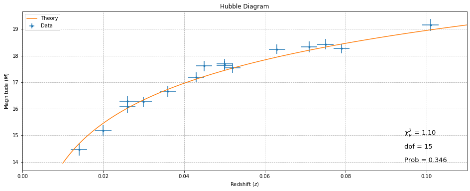

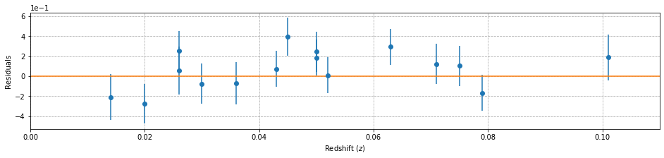

```python
"""
Program to read in magnitude vs redshift data from file 'HWK3_data.csv'
and plot data versus theory curve with an evaluation of
chi-squared and chi-squared probability
"""

# your code here...
import numpy as np
import matplotlib.pyplot as plt
import scipy.stats as st

%matplotlib inline

Z, Sig_z, Mag, Sig_M = np.loadtxt('HWK3_data.csv',delimiter=',',unpack=True)
f = plt.figure(figsize=(16,10))
f = plt.subplot2grid((5,1),(0,0),rowspan=3)
plt.errorbar(Z,Mag,xerr=Sig_z,yerr=Sig_M,fmt='.',label='Data');
m_z=(23.95)+5*np.log10(np.sort(Z))
Z_plot=np.linspace(0.01,0.11,100)
M_Z_plot=(23.95)+5*np.log10(Z_plot)
plt.plot(Z_plot,M_Z_plot,label='Theory')
plt.xlim(0,0.11)
plt.legend()
plt.title('Hubble Diagram')
plt.xlabel('Redshift ($z$)')
plt.ylabel('Magnitude ($M$)')
plt.ticklabel_format(axis='y',style='sci',scilimits=(0,3))

i = np.argsort(Z)
Mag=Mag[i]
Sig_M=Sig_M[i]
def chi_squared(Theory,Data,sigma):
    """
    This function calculates TOTAL chi-squared between Theory and Data using sigma
    as errors.
    The 3 arrays must be of equal size.
    Note: This is NOT reduced chi-squared
    Note: this neglects the errors in the "x-coordinate"
    Usage:
     inputs: Theory = input hypothesis (or Theory)
             Data = Data points
             sigma = uncertainty on data points
     output: if arrays are of equal size returns the TOTAL chi-squared
             if arrays are not of equal size returns -1.0
    """
    if np.size(m_z)==np.size(Mag) and np.size(Mag)==np.size(Sig_z):
        chi2=np.sum((m_z-Mag)**2/Sig_M**2)
        return chi2
    else:
        print('error - arrays of unequal size')
        return -1.

dof = np.size(Z)-1   #degrees of freedom
plt.text(.0945,14.5,'dof = {:g}'.format(dof),size=13)
chi2 = chi_squared(m_z,Mag,Sig_M)
chi_2 = chi2/dof
plt.text(.0945,15,r'$\chi_v^2$ = {:.2f}'.format(chi_2),size=13)
prob = st.chi2.sf(chi2,dof)   #probability function from scipy.stats
plt.text(.0945,14,r'Prob = {:.3g}'.format(prob),size=13)
plt.grid(True,linestyle='--')
plt.show()

plt.figure(figsize=(16,8))
plt.subplot2grid((5,1),(0,0),rowspan=2)
res=Mag-m_z
plt.errorbar(np.sort(Z),res,yerr=Sig_M,fmt='o')
plt.xlim(0,0.11)   #setting limits for x-axis
plt.plot([0,0.11],[0,0])   #plot flat line at residual=0 from x=0->.11
plt.xlabel('Redshift ($z$)')
plt.ylabel('Residuals')
plt.grid(True,linestyle='--')
plt.ticklabel_format(axis='y',style='sci',scilimits=(0,3))
```

```python
y=np.arange(1,5)
x=[1, 3, 2 ,4]
i=np.argsort(x)
y=y[i]
print(x)
print(y)
```

```
[1, 3, 2, 4]
[1 3 2 4]
```